# R Notebook

# Read the Data

```r
library(adegenet)
data = read.genepop('data/stickle.gen')
```

# Heterozygosity

First let’s look at the observed and expected heterozygosity

```r
data.pop = seppop(data)
data.het = cbind(do.call("c", lapply(data.pop, function(x) mean(summary(x)$Hobs))), do.call("c", lapply(data.pop, function(x) mean(summary(x)$Hexp))) )
colnames(data.het) = c('Observed heterozygosity', 'Expected heterozygosity')
data.het
```

```
      Observed heterozygosity Expected heterozygosity
Pop-1               0.7174418               0.7881554
Pop-2               0.6945932               0.7871591
Pop-3               0.7133605               0.8022704
Pop-4               0.7239355               0.7985027
Pop-5               0.6041739               0.6130383
Pop-6               0.5360000               0.5533600
Pop-7               0.4600714               0.4864783
```

# Calculating Genetic Diversity

```r
library(mmod)
diff_stats(data)
```

```
$per.locus
              Hs        Ht        Gst Gprime_st         D
Gac4b  0.7629263 0.8222908 0.07219402 0.3510510 0.2921393
Gac7b  0.7475179 0.8223185 0.09096304 0.4140439 0.3456378
Gac14b 0.3342903 0.4734715 0.29395895 0.4911068 0.2439172
Gac9b  0.7273810 0.9072275 0.19823743 0.8212199 0.7696488
Gac10b 0.9147719 0.9622071 0.04929834 0.6693335 0.6493291

$global
       Hs        Ht   Gst_est Gprime_st     D_het    D_mean
0.6973775 0.7975031 0.1255488 0.4740940 0.3860029 0.3772069
```

Let’s now calculate some measures of diversity at the global population level, rather than at the locus level. First calculate Weir and Cockerham 1984 Fst value

```r
library(hierfstat)
genet.dist(data, diploid = T, method = 'WC84')
```

```
           Pop-1      Pop-2      Pop-3      Pop-4      Pop-5      Pop-6
Pop-2 0.01770832
Pop-3 0.02722999 0.03735966
Pop-4 0.06386159 0.07531312 0.07095113
Pop-5 0.11643323 0.12364991 0.14921278 0.17677103
Pop-6 0.10865519 0.12334559 0.16555249 0.19069749 0.19758067
Pop-7 0.18272661 0.17273323 0.22439863 0.25348219 0.28878800 0.27744661
```

How do you interpret the values? Highest – lowest? Outlier? Map the values on the sampling map; do you notice a pattern? Values in the coastal region are comparable and above average for H and NA.

What about inbreeding (FIS) values as a measure of diversity?

```r
basic.stats(data)
```

```
$perloc
           Ho     Hs     Ht    Dst    Htp   Dstp    Fst   Fstp    Fis   Dest
Gac4b  0.7469 0.7631 0.8223 0.0592 0.8322 0.0691 0.0720 0.0830 0.0212 0.2916
Gac7b  0.7150 0.7479 0.8224 0.0745 0.8348 0.0869 0.0906 0.1041 0.0439 0.3447
Gac14b 0.2829 0.3348 0.4736 0.1387 0.4967 0.1618 0.2929 0.3258 0.1553 0.2433
Gac9b  0.5300 0.7297 0.9076 0.1779 0.9372 0.2075 0.1960 0.2214 0.2737 0.7677
Gac10b 0.9035 0.9149 0.9622 0.0473 0.9701 0.0552 0.0492 0.0569 0.0125 0.6488

$overall
    Ho     Hs     Ht    Dst    Htp   Dstp    Fst   Fstp    Fis   Dest
0.6357 0.6981 0.7976 0.0995 0.8142 0.1161 0.1248 0.1426 0.0894 0.3846
```

Significance: diversity is a suitable measure of biodiversity at the genetic level. Let’s visualise the output of the FST analysis with heat maps.

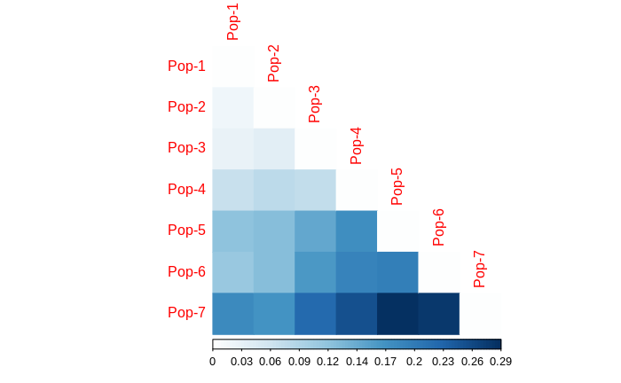

```r
pp = genet.dist(data, diploid = T, method = 'WC84')

library(corrplot)
corrplot(as.matrix(pp), is.cor = F, type= 'lower', method = "color")
```

# Calculating Overall Hierarchical Genetic Structure

We use AMOVA (Analysis of Molecular Variance) to calculate overall genetic structure by groupings based on the FST values. In order to do so we have to adapt the ‘data’ object with the grouping settings.

First we create a data frame that contains the hierarchical structure of the data:

```r
data_hier = data.frame(c(rep('coastal', 49+50+50+46), rep('inland', 50+50+50)), data@pop)
names(data_hier) = c('group', 'pop')
```

Now we add the dataframe to the dat object to make it a stratification factor

```r
data@other = list(population_hierarchy = data_hier)
strata(data) = data.frame(other(data)$population_hierarchy)
```

We can now check how the stratification looks like:

| group | pop |
| --- | --- |
| coastal | Pop-1 |
| coastal | Pop-1 |
| coastal | Pop-1 |
| coastal | Pop-1 |
| coastal | Pop-1 |
| coastal | Pop-1 |
| coastal | Pop-1 |
| coastal | Pop-1 |
| coastal | Pop-1 |
| coastal | Pop-1 |

[output cut: 335 more lines]

Even though the stratification looks like a simple data frame, it will be necessary to specify the terms of the AMOVA.

Note that we discard sample 7 (Meuse) for this analysis, since statistical tests are only valid if groups contain at least 2 populations. In case of one population, one may consider it anyway as a genetic unit.

```r
library(poppr)
data2 = popsub(data, blacklist = 'Pop-7')
```

```
          Locus
Population  Gac4b  Gac7b Gac14b  Gac9b Gac10b   Mean
     Pop-1      . 0.0612 0.0816 0.2041 0.1633 0.1020
     Pop-2 0.0200 0.0600      . 0.1400 0.0400 0.0520
     Pop-3 0.0200 0.0200      . 0.2000 0.0400 0.0560
     Pop-4      . 0.0652 0.1739 0.1739 0.1522 0.1130
     Pop-5      .      .      .      . 0.0800 0.0160
     Pop-6      .      . 0.0200      .      . 0.0040
     Total 0.0068 0.0339 0.0441 0.1186 0.0780 0.0563
```

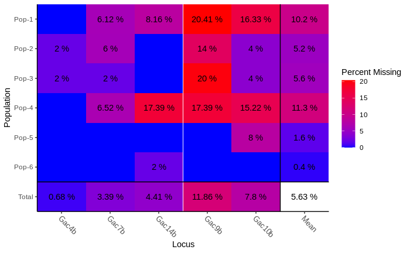

```r
info_table(data2, plot = TRUE)
```

We remove the missing data:

```r
data2 = missingno(data2, type = 'genotype')
```

```
Found 2020 missing values.

63 genotypes contained missing values greater than 5%

Removing 63 genotypes: 001, 002, 003, 006, 008, 009, 019, 022, 023, 028, 029, 033, 035, 038, 039, 043, 046, 047, 048, 049, 052, 056, 057, 058, 068, 070, 095,
096, 099, 100, 103, 112, 116, 117, 118, 120, 137, 140, 141, 144, 145, 147, 155, 159, 161, 167, 168, 176, 177, 179, 186, 187, 188, 191, 192, 193, 194, 195, 204,
236, 241, 245, 293
```

Let’s finally run the AMOVA:

```r
stickamova = poppr.amova(data2, ~group/pop, within = F)
```

```
 No missing values detected.
```

```r
stickamova
```

```
$call
ade4::amova(samples = xtab, distances = xdist, structures = xstruct)

$results
                              Df    Sum Sq   Mean Sq
Between group                  1  41.54596 41.545964
Between samples Within group   4  65.42529 16.356322
Within samples               226 436.64728  1.932068
Total                        231 543.61853  2.353327

$componentsofcovariance
                                             Sigma          %
Variations  Between group                0.2072163   8.205728
Variations  Between samples Within group 0.3859802  15.284744
Variations  Within samples               1.9320676  76.509528
Total variations                         2.5252641 100.000000

$statphi
                         Phi
Phi-samples-total 0.23490472
Phi-samples-group 0.16651087
Phi-group-total   0.08205728
```

Are your results significant? To test this we will run a permutation test and see where our results sit in the output:

```r
set.seed(1999)
sticksignif = randtest(stickamova, nrepet = 999)

sticksignif
```

```
class: krandtest lightkrandtest
Monte-Carlo tests
Call: randtest.amova(xtest = stickamova, nrepet = 999)

Number of tests:   3

Adjustment method for multiple comparisons:   none
Permutation number:   999
```

|  | Test | Obs | Std.Obs | Alter | Pvalue |
| --- | --- | --- | --- | --- | --- |
| 1 | Variations within samples | 1.9320676 | -61.017869 | less | 0.001 |
| 2 | Variations between samples | 0.3859802 | 45.180250 | greater | 0.001 |
| 3 | Variations between group | 0.2072163 | 2.805898 | greater | 0.001 |

```
NA
```

What is your outcome of the AMOVA? What is an AMOVA exactly? Explain with your own words. How do you interpret the hierarchical pattern?

# Conclusion

Population genetic samples reveal their genetic diversity and patterns through a diversity of statistical analyses.